# Ejercicios de clase

## Ejercicio 1

Escribir una función mediaColumnas que calcule la media de las columnas de un data.frame que se pasa como argumento usando un bucle y las devuelva en un vector. La función debe comprobar que el argumento es un data.frame.

```r
mediaColumnas <- function(df){
 if (!is.data.frame(df)){
   print("El argumento no es un dataframe")
   return(NA)
  }
 media <- array()
 for (idx in seq_along(df)){
   media[idx] <- mean(df[,idx], rm.na=TRUE)
   }
 media
}
```

Generar un data.frame de 1,000 filas y 100,000 columnas con números aleatorios con distribución normal con media 10 y desviación 2.

```r
cols = 100000
rows = 1000

df <- as.data.frame(matrix(rnorm(cols*rows, 10, 2), ncol = cols, nrow = rows))
```

Utilizar la función anterior para calcular la media de las columnas de los datos del data.frame.

```r
t1 <- system.time(mediaColumnas(df))[3]
```

Hacer la misma operación anterior pero ahora con la función sapply.

```r
t2 <- system.time(sapply(df, mean))[3]
```

Comparar el tiempo de ejecución de los dos procedimientos anteriores.

```r
print(paste0("Tiempo de ejecución de mediaColumna: ", t1))
```

```
## [1] "Tiempo de ejecución de mediaColumna: 11.19"
```

```r
print(paste0("Tiempo de ejecución de mean: ", t2))
```

```
## [1] "Tiempo de ejecución de mean: 0.59"
```

## Ejercicio 2

Generar 10000 números aleatorios con una distribución normal estándar (media 0 y varianza 1).

```r
a <- rnorm(10000)
```

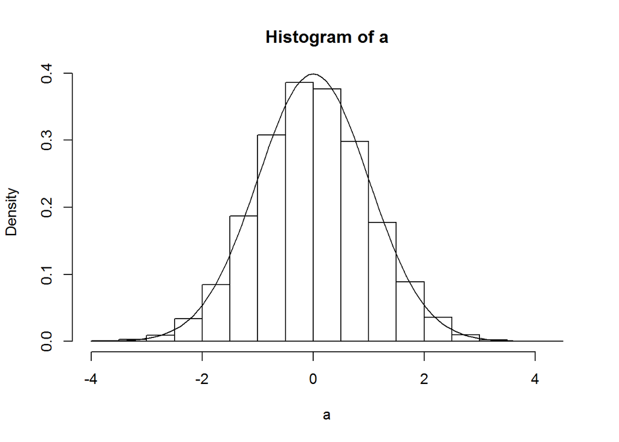

```r
hist(a, probability = T)
curve(dnorm(x), -4, 4, add=T)
```

Calcular los valores de la distribución normal para 100 puntos en el intervalo anterior, utilizando las función seq() y dnorm().

```r
x <- seq(-4, 4, length.out = 100)
y <- dnorm(x)
```

Superponer los valores de la distribución normal calculados al histograma (función lines()). ¿Se aproxima el histograma a la curva calculada?

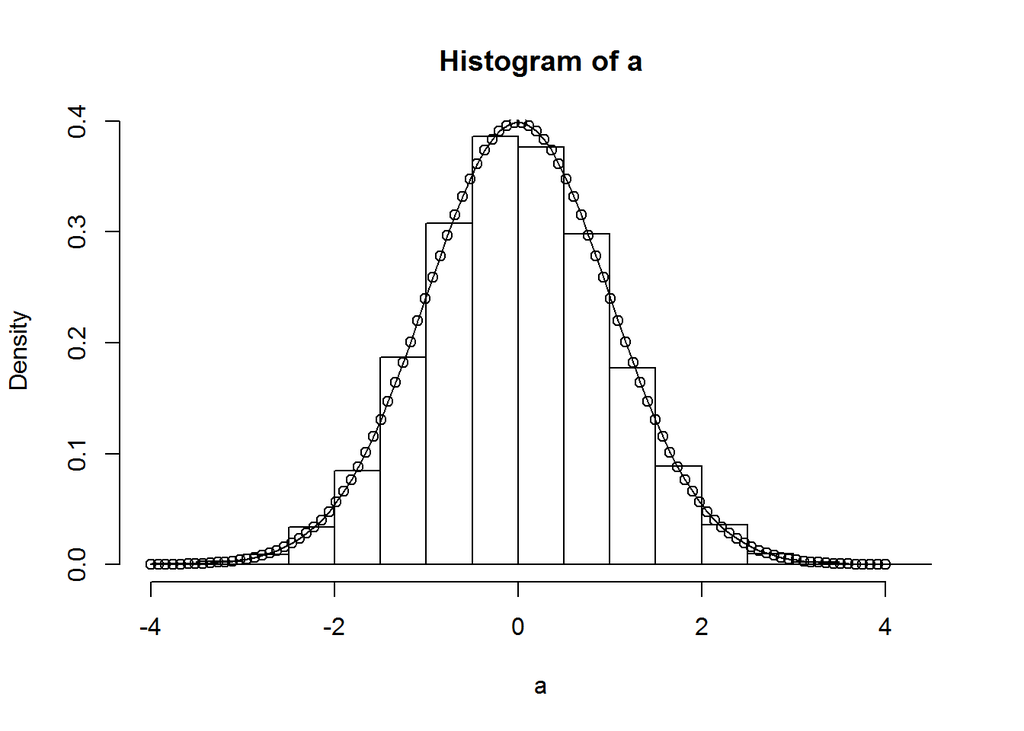

```r
hist(a, probability = T)
lines(x, y)
points(x, y)
```